# Bolivia Studies Journal Data Page

Carwil Bjork-James

11/16/2022

This page is supplementary material to Carwil Bjork-James’s article, “Tactics of political violence in the 2019 Bolivian crisis: Return of the catastrophic stalemate?,” to be published in the Bolivian Studies Journal.

All queries and data tables referenced in the article are compiled in BSJ-Political-Violence.Rmd in the Ultimate Consequences package on GitHub, using the database as constituted on November 16, 2022. A copy of the database on that date is archived for reproducibility of the analysis. Access is currently available to researchers on request and will be incorporated into the forthcoming public release of the dataset. The queries, data tables, and code used to create them are published online as Bjork-James 2022 at https://ultimateconsequences.github.io/BSJ-Political-Violence.html.

This document is designed to enable transparency and reproducibility of our research results. By specifying our search criteria for relevant cases, explaining exceptions, and embedding our analysis techniques in R scripts that use the database, we document our choices and create tools that can automatically update results when additional cases are uncovered, errors are corrected, or new information is brought to light. Archiving and versioning of the database and these tools allows other researchers to both reproduce our results, and test their robustness against different choices in coding or analysis.

This document is divided into two parts. Unless you are attempting to reproduce our results from the dataset, feel free to skip over **Preparatory Code Blocks**, and begin reading at **Calculations and Queries Used in the Article**.

For more information about the Ultimate Consequences research project, database, and future testimonial archive, head to our Project Overview page.

# Preparatory Code Blocks

The following sections show all code in R needed to read and process the database. It is included here to allow researchers using R to reproduce the analysis from an archived copy of the dataset. Similarly, text below documents the standard importing, filtering, and processing of the data.

```r
## This Rmarkdown script uses the following libraries. You may need to run one of the two scripts
## #`install-packages.R` or `install-common-packages.R` first if these packages aren't already loaded into RStudio. ## (Both scripts do the same thing, but `install-packages.R` is written in a more elegant way.)

library(googlesheets4)
library(googledrive)
library(tidyr)
library(readr)
library(plyr) # should be invoked before dplyr
library(dplyr)
library(stringr)
library(reactable)
library(forcats)
library(ggplot2)
library(ggtext)
library(ggalluvial)
library(skimr)
library(stringr)
library(janitor) # for tabyl
library(flextable)
library(scales)
library(GGally)
library(webshot)
library(magick)
library(knitr)
library(kableExtra)
library(forcats)
library(ggfittext)
library(hrbrthemes)
library(janitor)
```

# First, import the data from Google Sheets or retrieve it from the package

This code can either live-import the dataset from its Google Sheets instantiation or reload an already imported dataset stored in the GitHub package. The former will only run successfully if… - You have been granted access to the Google Sheet - You have the “Bolivia Deaths Database” in the root directory of your Google Drive. - You accept giving “Tidyverse API” access to your Google Drive.

Doing this is **not** needed for reproducibility of the results. Just keep the code as-is below and you will access the database as it was imported at the time of final article submision.

This code segment applies a set of standard filters:

- Culling out currently inactive variables using `select`
- Segmenting out parenthetical annotations using `separate`: `Answer (explanation)` is split into two separate variables, the first holding a categorical variable, and the second holding the corresponding notes.

We also import a basic table of presidential terms from the database.

```r
live.import <- FALSE

de.filename <- "data/deaths-entries-2022-11-16.rds"
pt.filename <- "data/presidents-table-2022-11-16.rds"
use.current.archive <- FALSE # This flag should be set to true when
                            # the above filenames do not have a date

if (live.import){
  # Import the Entries
  source("src/import-deaths-database.R")
  source("src/update-versioned-archive.R")
  de <- import_deaths_database(incl_inactive=FALSE, incl_narrative=FALSE,
                               parse_parenthical=TRUE)

  #
  # Save current version of the file to data/
  #
  #
  de.filename.dated <- update_versioned_archive(de, de.filename)

  # Import the presidents table
  pt <- import_presidents_table()
  pt.filename.dated <- update_versioned_archive(pt, pt.filename)

}else
{
  de <- read_rds(de.filename)
  pt <- read_rds(pt.filename)

    if(use.current.archive){ # if the filenames are undated,
                           # use the most recent archived file as
                           # the file name in question
                           #
                           # (potential future upgrade: check that the
                           # undated file contains the same data as this file)
    filelist <-file.info(list.files(path="data", pattern="deaths-entries-.*"), extra_cols = FALSE)
    filelist <- filelist[with(filelist, order(as.POSIXct(mtime))), ]
    files <- rownames(filelist)
    de.filename.dated <- paste("data/", tail(files, 1), sep="")

    filelist <-file.info(list.files(path="data", pattern="presidents-table-.*"), extra_cols = FALSE)
    filelist <- filelist[with(filelist, order(as.POSIXct(mtime))), ]
    files <- rownames(filelist)
    pt.filename.dated <- paste("data/", tail(files, 1), sep="")
    }else                 # ... conversely if the filenames are already dated, we want these to apppear
                          # in our data files footer below.
    {
      de.filename.dated <- de.filename
      pt.filename.dated <- pt.filename
    }
}

de.imported <- de # keep a copy around for debugging

# de <- def # AUTOFILTERING. Comment out when we want to consider the whole dataset
          # Also, eventually we may want to handle "unconfirmed" in a more complex way
          #   At that point, we will no longer filter for it, but pass it through.


# clean up the variable names
pt <- rename_with(pt, ~ sub(" \\(.*", "", .x))
pt <- rename_with(pt, ~ tolower(gsub(" ", "_", .x, fixed = TRUE)))
pt <- rename_with(pt, ~ gsub("frequency_of_", "", .x, fixed = TRUE))
pt <- rename_with(pt, ~ gsub("-", "_", .x, fixed = TRUE))
pt <- rename_with(pt, ~ gsub("/", "_", .x, fixed = TRUE))
pt <- rename_with(pt, ~ gsub("?", "", .x, fixed = TRUE))

# return the list to verify the cleaning worked
# glimpse(pt2)

# create a smaller presidents table just for the study period
studyperiod.start <- as.Date("1982-10-10")
studyperiod.end <- Sys.Date()
pt.study <- pt %>% filter((first_day >= studyperiod.start) & (last_day <= studyperiod.end))

datafiles_footer <- function(de=TRUE, pt=FALSE, es=FALSE){
  datafile_text <- ""
  if(de){
    datafile_text <- paste(datafile_text, "**Entries:**", de.filename.dated, sep=" ")
  }

  if(pt){
    datafile_text <- paste(datafile_text, "**Presidents:**", pt.filename.dated, sep=" ")
  }

  if(es){
    datafile_text <- paste(datafile_text, "**Event Status:**", es.filename.dated, sep=" ")
  }

  str_trim(datafile_text)
}
```

# Next, process the variables

First, we want to think through which variables are involved. They are:

- `pres_admin` — who was the president?
- `protest_domain` — The broad arena of politial conflict. Tells us whether to count something as a coca death, or an armed actor death
- `state_perpetrator` — Was this death perpetrated by the state?

These are standard blocks of code, which currently appear in Database Overview.Rmd, and eventually will find a home in a variable set-up function. What does this code do?

```r
library(janitor) # for tabyl

## Factoring: Presidential administration

president_levels <- c(
  "Hernán Siles Zuazo", "Víctor Paz Estenssoro", "Jaime Paz Zamora",
  "Gonzalo Sanchez de Lozada (1st)", "Hugo Banzer (2nd)", "Jorge Quiroga",
  "Gonzalo Sanchez de Lozada (2nd)", "Carlos Diego Mesa Gisbert",
  "Eduardo Rodríguez", "Evo Morales", "Interim military government",
  "Jeanine Áñez", "Luis Arce") # All presidencies, in chronological order
president_initials <- c(
  "HSZ", "VPE", "JPZ",
  "GSL", "HB", "JQ",
  "GSL", "CM",
  "ER", "EM", "Mil",
  "JA", "LA")

de <- de %>% mutate(pres_admin=factor(pres_admin, levels=president_levels))
de %>% tabyl(pres_admin)  %>%
  adorn_totals("row") %>%
  adorn_pct_formatting()
```

```
##                       pres_admin   n percent
##               Hernán Siles Zuazo   8    1.2%
##            Víctor Paz Estenssoro  43    6.7%
##                 Jaime Paz Zamora  21    3.3%
##  Gonzalo Sanchez de Lozada (1st)  51    7.9%
##                Hugo Banzer (2nd) 121   18.8%
##                    Jorge Quiroga  33    5.1%
##  Gonzalo Sanchez de Lozada (2nd) 146   22.7%
##        Carlos Diego Mesa Gisbert  19    3.0%
##                Eduardo Rodríguez   0    0.0%
##                      Evo Morales 148   23.0%
##      Interim military government   9    1.4%
##                     Jeanine Áñez  26    4.0%
##                        Luis Arce  19    3.0%
##                            Total 644  100.0%
```

```r
## Factoring: State perpetrator (a quasilogical variable)
de %>% tabyl(state_perpetrator)  %>%
  adorn_totals("row") %>%
  adorn_pct_formatting()
```

```
##  state_perpetrator   n percent valid_percent
##           Disputed   4    0.6%          0.6%
##          In mutiny   5    0.8%          0.8%
##           Indirect  15    2.3%          2.4%
##          Likely no   3    0.5%          0.5%
##         Likely Yes   4    0.6%          0.6%
##                 No 286   44.4%         45.8%
##       Presumed yes   2    0.3%          0.3%
##       Presumed Yes   7    1.1%          1.1%
##            Unknown   1    0.2%          0.2%
##                Yes 298   46.3%         47.7%
##               <NA>  19    3.0%             -
##              Total 644  100.0%        100.0%
```

```r
de$state_perpetrator <- fct_explicit_na(de$state_perpetrator, na_level = "Unknown")
de$state_perpetrator <- fct_collapse(de$state_perpetrator,
                                     Yes = c("Yes", "Likely Yes", "Presumed Yes", "Presumed yes"),
                                     Indirect = c("Indirect"),
                                     No = c("No", "Likely no"),
                                     Mutiny = c("In mutiny"),
                                     Unknown  = c("Unknown", "Disputed", "Suspected") )
de$state_perpetrator <- fct_relevel(de$state_perpetrator,
                                    c("Unknown", "No", "Indirect", "In mutiny", "Yes"))
de %>% tabyl(state_perpetrator)  %>%
  adorn_totals("row") %>%
  adorn_pct_formatting()
```

```
##  state_perpetrator   n percent
##            Unknown  24    3.7%
##                 No 289   44.9%
##           Indirect  15    2.3%
##                Yes 311   48.3%
##             Mutiny   5    0.8%
##              Total 644  100.0%
```

```r
## Factoring: State perpetrator (a categorical variable)
de.imported %>% tabyl(state_responsibility)  %>%
  adorn_totals("row") %>%
  adorn_pct_formatting() # Look at it before
```

```
##                             state_responsibility   n percent valid_percent
##                                 Political victim   2    0.3%          0.3%
##         Political victim / political perpetrator   1    0.2%          0.2%
##           Political victim / unknown perpetrator   3    0.5%          0.5%
##                              Separate from state 197   30.6%         31.6%
##                              Seperate from state   1    0.2%          0.2%
##                       State indirect perpetrator   3    0.5%          0.5%
##                                   State involved  46    7.1%          7.4%
##                         State likely perpetrator   5    0.8%          0.8%
##                                State perpetrator 291   45.2%         46.6%
##        State perpetrator, State victim in mutiny   9    1.4%          1.4%
##  State perpetrator, State victim refusing orders   1    0.2%          0.2%
##                                     State victim  60    9.3%          9.6%
##        State victim, State perpetrator in mutiny   5    0.8%          0.8%
##                                             <NA>  20    3.1%             -
##                                            Total 644  100.0%        100.0%
```

```r
# This code lets us look ta relevant cases of unintential death
#
# de %>% filter((intentionality=="Conflict Accident")|(intentionality=="Nonconflict Accident")|
#                 (intentionality=="Incidental")) -> de.acc
#
# de.acc %>% tabyl(state_responsibility)
# de.acc %>% filter(state_responsibility=="Victim")

de <- de %>% mutate(state_responsibility = case_when(    # overwrite the state responsibility for unintentional cases
                                   intentionality == "Incidental" ~ "Incidental",
                                   intentionality == "Conflict Accident" ~ "Accidental",
                                   TRUE ~ state_responsibility))

de$state_responsibility <- fct_explicit_na(de$state_responsibility, na_level = "Unknown")
de$state_responsibility <- fct_collapse(de$state_responsibility,
                             Perpetrator = c("State perpetrator", "State likely perpetrator",
                                             "State perpetrator, State victim refusing orders",
                                             "State perpetrator, State victim in mutiny",
                                             "State indirect perpetrator"),
                             Involved = c("State involved", "Political victim",
                                          "Political victim / political perpetrator",
                                          "Political victim / unknown perpetrator",
                                          "Possibly state involved"),
                             Victim = c("State victim",
                                        "State victim, State perpetrator in mutiny"),
                             Separate = c("Separate from state"),
                             Unintentional = c("Incidental", "Accidental"),
                             Unknown  = c("Unknown", "Unclear") )
sr_levels <- c("Perpetrator", "Victim", "Involved", "Separate", "Unintentional", "Unknown")
de$state_responsibility <- fct_relevel(de$state_responsibility, sr_levels)

state_resp.colors <-  c(
  Perpetrator = "forestgreen",
  Victim = "firebrick4",
  Involved = "lightgreen",
  Separate = "goldenrod2",
  Unintentional = "darkgray",
  Unknown = "lightgray")

de %>% tabyl(state_responsibility)  %>%
  adorn_totals("row") %>%
  adorn_pct_formatting() # Look at it after
```

```
##  state_responsibility   n percent
##           Perpetrator 307   47.7%
##                Victim  63    9.8%
##              Involved  28    4.3%
##              Separate 191   29.7%
##         Unintentional  36    5.6%
##               Unknown  18    2.8%
##   Seperate from state   1    0.2%
##                 Total 644  100.0%
```

Note that this leaves us with two variables for understanding the state’s role.

The “standard filters” on the dataset remove the following cases:

[output not shown]

```r
def <- de %>%
  filter(is.na(unconfirmed) | unconfirmed != TRUE) %>%
  filter(is.na(intentionality) | intentionality != "Collateral") %>%
  filter(is.na(intentionality) | intentionality != "Nonconflict Accident") %>%
  filter(is.na(intentionality) | intentionality != "Nonconflict")

de.confirmed <- def
```

### Function to generate a summary data table based on on variable

```r
## Make a generic function to summarize deaths according to the columns
## in our Categorized Deaths table
n_categorized_by <- function(de, by, complete = FALSE){
  output <- de %>%
    filter(!is.na({{by}})) %>%
    filter({{by}} != "") %>%
    group_by( {{ by }} ) %>%
    dplyr::summarize(
      n = n(), # all deaths
      n_coca = sum(str_detect(protest_domain, "Coca"), na.rm = TRUE), #coca deaths
      n_armedactor =sum((protest_domain=="Guerrilla") |
                          ( protest_domain == "Paramilitary"),
                        na.rm = TRUE), # armed actor death
      n_state_perp = sum(state_perpetrator=="Yes", na.rm = TRUE), #state perp
      n_state_perp_coca = sum(((state_perpetrator=="Yes") & (str_detect(protest_domain, "Coca"))), na.rm = TRUE), #state perp coca death
      n_state_perp_armedactor = sum((state_perpetrator=="Yes" & ((protest_domain=="Guerrilla") | ( protest_domain == "Paramilitary" ))), na.rm = TRUE), #state perp armed actor death,
      n_state_perp_ordinary = n_state_perp - n_state_perp_armedactor - n_state_perp_coca, # all other state perp deaths
      n_state_victim = sum(state_responsibility=="Victim", na.rm = TRUE), # state victim
      n_state_victim_coca = sum(((state_responsibility=="Victim") &
                                   (str_detect(protest_domain, "Coca"))), na.rm = TRUE), #state victim coca death
      n_state_victim_armedactor = sum(((state_responsibility=="Victim") &
                                         ((protest_domain=="Guerrilla") |
                                            (protest_domain == "Paramilitary"))), na.rm = TRUE), #state victim armed actor death
      n_state_victim_ordinary = n_state_victim - n_state_victim_armedactor - n_state_victim_coca, # all other state perp deaths
      n_state_separate = sum(str_detect(state_responsibility, "Separate"), na.rm = TRUE),
      n_remaining = n - n_state_perp - n_state_victim,
      n_remaining_coca = n_coca - n_state_perp_coca - n_state_victim_coca,
      n_remaining_armedactor = n_armedactor - n_state_perp_armedactor - n_state_victim_armedactor
    )

  if(complete){
    output <- output %>%
      complete({{by}}, fill =list(
        n = 0,
      n_coca = 0,
      n_armedactor = 0,
      n_state_perp = 0,
      n_state_perp_coca = 0,
      n_state_perp_armedactor = 0,
      n_state_perp_ordinary = 0,
      n_state_victim = 0,
      n_state_victim_coca = 0,
      n_state_victim_armedactor = 0,
      n_state_perp_ordinary = 0,
      n_state_separate = 0,
      n_remaining = 0,
      n_remaining_coca = 0,
      n_remaining_armedactor = 0
      ))
  }

  return(output)
}
```

# Calculations and Queries Used in the Article

### Deadliest events

> Thirty-eight lives were lost during the crisis, a toll only exceeded by the September–October 2003 Gas War (with 70 deaths), though closely followed by the February 2003 tarifazo tax protests (35 deaths).

```r
de.confirmed %>% tabyl(event_title) %>% filter(n>20) %>% select(-percent) %>% arrange(desc(n))
```

```
##           event_title  n
##          2003 Gas War 70
##  Tarifazo tax protest 35
##  Laymi-Qaqachaka 2000 29
##     Plan Dignity 1998 23
```

### An overall breakdown

```r
n_entries <- count(de)
n_confirmed <- count(def)

n_unconfirmed <- sum(de$unconfirmed == TRUE, na.rm =TRUE)

de_excluded <- de %>%
  filter(intentionality == "Collateral"
         | intentionality == "Nonconflict Accident"
         | intentionality == "Nonconflict")
n_excluded <- count(de_excluded)
n_collateral <- sum(de$intentionality == "Collateral", na.rm = TRUE)
n_nonconfaccident <- sum(de$intentionality == "Nonconflict Accident", na.rm = TRUE)
n_nonconfdeath <- sum(de$intentionality == "Nonconflict", na.rm = TRUE)

de_named <- de %>%
  filter(!is.na(dec_firstname) & !is.na(dec_surnames) )
n_named <- count(de_named)
```

> The database includes 626 to 644 of these deaths, including those of 595 named individuals.

> Note: Of the 644 deaths recorded in the database, 18 are “unconfirmed” deaths corresponding to cases where an uncertain number of people were killed (e.g., if “three to five” people were reported killed, two unnamed individuals are included in the database as unconfirmed deaths). There are 13 recorded instances of non-conflict-related accidents and 3 non-conflict-related natural deaths associated with protest events; and 5 recorded instances of deaths from medical causes, where protest or repression may have impeded medical care (“collateral”). For the remainder of this article, we refer to the 605 deaths not excluded for any of these reasons as “confirmed deaths.”

### Arson Deaths

> During the past four decades, there were only two deadly protest arsons in Bolivia: two Qaqachaka residents were killed when their home was burned in 1996; and a fire set by a protesting parents’ group at the El Alto City Hall in 2016 caused the deaths of five municipal workers.

```r
de.confirmed %>% filter(cause_death=="Fire") %>%
                 select(event_title, year, dec_firstname, dec_surnames, cause_death, intentionality)
```

```
## # A tibble: 13 × 6
##    event_title        year dec_firstname dec_surnames cause_death intentionality
##    <chr>             <int> <chr>         <chr>        <chr>       <chr>
##  1 Laymi-Qaqachaka …  1996 <NA>          <NA>         Fire        Direct
##  2 Laymi-Qaqachaka …  1996 <NA>          <NA>         Fire        Direct
##  3 2003 Gas War       2003 Braulio       Callisaya D… Fire        Conflict Acci…
##  4 2003 Gas War       2003 Raul          Flores Huan… Fire        Conflict Acci…
##  5 2003 Gas War       2003 Florentino    Poma Flores  Fire        Conflict Acci…
##  6 2003 Gas War       2003 Benita        Rodriguez (… Fire        Conflict Acci…
##  7 2003 Gas War       2003 Dominga       Rodriguez (… Fire        Conflict Acci…
##  8 Santa Cruz lotea…  2010 Marco Antonio Gómez Carra… Fire        Direct
##  9 El Alto City Hal…  2016 Ana María     Apaza Alano… Fire        Direct
## 10 El Alto City Hal…  2016 Javier        Mollericona… Fire        Direct
## 11 El Alto City Hal…  2016 José Rodrigo  Cortez Flor… Fire        Direct
## 12 El Alto City Hal…  2016 Rosmery       Mamani Pauc… Fire        Direct
## 13 El Alto City Hal…  2016 Gloria Magaly Calle Suarez Fire        Direct
```

```r
de.confirmed %>% filter(weapon=="Arson") %>%
                 select(event_title, year, dec_firstname, dec_surnames, cause_death, intentionality)
```

```
## # A tibble: 7 × 6
##   event_title         year dec_firstname dec_surnames cause_death intentionality
##   <chr>              <int> <chr>         <chr>        <chr>       <chr>
## 1 Laymi-Qaqachaka 1…  1996 <NA>          <NA>         Fire        Direct
## 2 Laymi-Qaqachaka 1…  1996 <NA>          <NA>         Fire        Direct
## 3 El Alto City Hall…  2016 Ana María     Apaza Alano… Fire        Direct
## 4 El Alto City Hall…  2016 Javier        Mollericona… Fire        Direct
## 5 El Alto City Hall…  2016 José Rodrigo  Cortez Flor… Fire        Direct
## 6 El Alto City Hall…  2016 Rosmery       Mamani Pauc… Fire        Direct
## 7 El Alto City Hall…  2016 Gloria Magaly Calle Suarez Fire        Direct
```

> A sixth worker was beaten to death. In addition, police fatally shot a protesting university student during the attempted destruction of the Transit Police building in Sucre on November 25, 2007, and policeman Juan Alcón Parra was fatally beaten as protesters took over and ultimately burned the Regional Police Command in El Alto on November 11, 2019.

Descriptions retrieved from the database narratives.

### Security Force Shootings

```r
de.spgunshot <- de.confirmed %>% filter(cause_death=="Gunshot" & state_perpetrator == "Yes") %>%
                 select(event_title, year, dec_firstname, dec_surnames, cause_death, intentionality,
                        perp_category)

de.spgunshot.table <- de.spgunshot %>% tabyl(event_title) %>% filter(n>=3) %>%
                                       select(-percent) %>% arrange(desc(n))

de.spgunshot.table
```

```
##                                event_title  n
##                               2003 Gas War 53
##                       Tarifazo tax protest 28
##                           Senkata Massacre 11
##                            Sacaba massacre 10
##                     Chayanta mining strike  8
##         CSUTCB mobilization September 2000  8
##                      Jan 2003 coca clashes  7
##                          Plan Dignity 1998  7
##             Chapare cocalero protests 2001  6
##                      Eterazama eradication  5
##        Sacaba-Chapare coca market conflict  5
##                      Villa Tunari Massacre  5
##                   Cooperative miner strike  4
##                  Isinuta DEA confrontation  4
##                        La Paz raid on CNPZ  4
##  Santa Ana de Yacuma drug trafficking raid  4
##                      Coca eradication 1995  3
##             CSUTCB mobilization April 2000  3
##           La Paz post-resignation violence  3
##                           Pensioner strike  3
##             Santa Cruz raid on Rosza group  3
```

```r
n_spgunshot.events <- nrow(de.spgunshot.table)

n_spgushot.bystanders <- de.confirmed %>% filter((cause_death=="Gunshot" & state_perpetrator == "Yes")&
                                                  (intentionality=="Bystander")) %>%
                                          count()
n_spgushot.bystanders_hi <- de.confirmed %>% filter((cause_death=="Gunshot" & state_perpetrator == "Yes")&
                                                  (intentionality=="Bystander" |
                                                   intentionality == "Direct / Bystander")) %>%
                                          count()
```

> There have been at least 21 events in which security forces shot three or more people during protests, and 28 to 43 times that security forces killed bystanders, often by firing indiscriminately beyond those protesting.

### Deadliest events and Gas War summary

> The Sacaba and Senkata massacres were the deadliest episodes of state violence since the 2003 Gas War, when the security forces killed 59 people over four weeks. Forty-eight of them died the weekend of October 11–13, 2003, when a militarized convoy ran another blockade at Senkata.

This code first creates a table of all events with at least 10 state-perpetrated deaths, sorted chronologically by year and month. Next it creates a table of Gas War deaths, counts them, and provides a list by date of deadly incident.

```r
events.table <- def %>% group_by(event_title, year, month) %>%
  summarize(
    n = n(),
    n_state_perp = sum(state_perpetrator=="Yes", na.rm = TRUE),
    n_state_victim = sum(state_responsibility=="State victim", na.rm = TRUE),
    n_state_separate = sum(str_detect(state_responsibility, "Separate from state"), na.rm = TRUE)
  )
events.table %>% filter(n_state_perp>=10) %>% arrange(year, month)
```

```
## # A tibble: 7 × 7
## # Groups:   event_title, year [7]
##   event_title      year month     n n_state_perp n_state_victim n_state_separate
##   <chr>           <int> <int> <int>        <int>          <int>            <int>
## 1 Villa Tunari M…  1988     6    10           10              0                0
## 2 Chayanta minin…  1996    12    11           10              0                0
## 3 Plan Dignity 1…  1998     4    12           11              0                0
## 4 Tarifazo tax p…  2003     2    35           29              0                0
## 5 2003 Gas War     2003    10    65           55              0                0
## 6 Sacaba massacre  2019    11    10           10              0                0
## 7 Senkata Massac…  2019    11    11           11              0                0
```

```r
## Gas War calculations
def.gaswar.sp <- def %>% filter(protest_campaign=="2003 Gas War") %>%
                         filter(state_perpetrator=="Yes")  # table of state perpetrator deaths in the 2003 Gas War
n_gaswar.sp <- nrow(def.gaswar.sp) # count them

def.gaswar.sp %>% select(year, month, day, dec_firstname, dec_surnames) #output a table with dates and names
```

```
## # A tibble: 59 × 5
##     year month   day dec_firstname                         dec_surnames
##    <int> <int> <int> <chr>                                 <chr>
##  1  2003     9    20 Demetrio (Primitivo)                  Coraca Castro
##  2  2003     9    20 Juan                                  Cosme Apaza
##  3  2003     9    20 Simael Marcos (Ismael, Gilmer Marcos) Quispe Quispe (Quisp…
##  4  2003     9    20 Marlene Nancy                         Rojas Ramos
##  5  2003    10     9 José Luis                             Atahuichi Ramos
##  6  2003    10     9 Ramiro                                Vargas Astilla
##  7  2003    10    11 Walter                                Huanca Choque
##  8  2003    10    11 Alex                                  Llusco Mollericona
##  9  2003    10    11 Raul                                  Marca Ruiz
## 10  2003    10    11 José Miguel                           Pérez Cortez
## # … with 49 more rows
```

### Table 3

> Overall conflict deaths declined sharply as well, though not quite to the levels that had reigned prior to 2000. The Morales years did see repeated episodes of violence between civilian groups: partisans and those in local disputes over mines and land. The first three weeks of the 2019 crisis continued this trend. Table 3

This statement about repression relies on dividing time up into five periods. (Rather than drawing a conclusion about the brief and ongoing Arce government, I leave it off the table in the article.)

```r
presidents.calm=str_c("Carlos Diego Mesa Gisbert", "Eduardo Rodríguez", "Evo Morales", sep = "|")
presidents.righti=str_c("Interim military government", "Jeanine Áñez", sep = "|")

def.periods <- def %>% mutate(period = case_when(
  year < 2000 ~ "A. Oct 1982–1999",
  (year>=2000)&(year<2003) ~ "B. 2000–2003",
  (year == 2003) & (str_detect(string = pres_admin, pattern="Gonzalo Sanchez de Lozada \\(2nd\\)"))~ "B. 2000–2003",
  str_detect(string = pres_admin, pattern=presidents.calm) ~ "C. 2004–Nov 2019",
  str_detect(string = pres_admin, pattern=presidents.righti) ~ "D. Nov 2019–Nov 2020",
  (pres_admin=="Luis Arce") ~ "E. Nov 2020-present",
  TRUE ~ ""))

def.periods %>% select(event_title, year, period) -> defpcheck # simplify to make sure it worked

repression.periods.categorized <- def.periods %>%
  n_categorized_by(period, complete=TRUE) %>%
  select(period, n, n_state_perp) %>%
  mutate(perc_state_perp = percent(n_state_perp / n, digits = 0) )

repression.periods.categorized <-
  repression.periods.categorized %>% mutate(days=c(
           -as.numeric(difftime("1982-10-10", "2000-01-01", units = "days")),
           -as.numeric(difftime("2000-01-01", "2003-10-19", units = "days")),
           -as.numeric(difftime("2003-10-19", "2019-11-10", units = "days")),
           -as.numeric(difftime("2019-11-10", "2020-11-08", units = "days")),
           -as.numeric(difftime("2020-11-08", "2022-11-16", units = "days"))), .after=period)

repression.periods.categorized <-
  repression.periods.categorized %>%
  mutate(years=days/365, .after=days) %>%
  mutate(n_peryear=n/years, .after=n)  %>%
  mutate(sp_peryear=n_state_perp/years, .after=n_state_perp)

repression.periods.categorized
```

```
## # A tibble: 5 × 8
##   period     days  years     n n_peryear n_state_perp sp_peryear perc_state_perp
##   <chr>     <dbl>  <dbl> <dbl>     <dbl>        <dbl>      <dbl> <chr>
## 1 A. Oct 1… 6292. 17.2     155      8.99           97       5.63 62.6%
## 2 B. 2000–… 1387.  3.80    245     64.5           138      36.3  56.3%
## 3 C. 2004–… 5866. 16.1     154      9.58           40       2.49 26.0%
## 4 D. Nov 2…  364   0.997    34     34.1            30      30.1  88.2%
## 5 E. Nov 2…  738   2.02     17      8.41            0       0    0.0%
```

### Figure 1

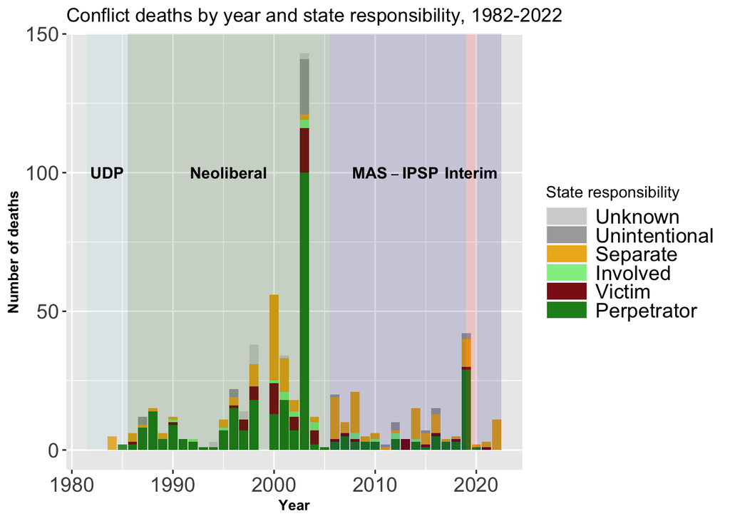

```r
plot <- def %>% filter(!is.na(protest_domain)) %>%
  ggplot(aes(x= year, fill = forcats::fct_rev(state_responsibility))) +
  geom_bar() +
 scale_fill_manual(limits = sr_levels, values = state_resp.colors, guide = guide_legend(reverse=TRUE)) +
  ggtitle("Conflict deaths by year and state responsibility, 1982-2022") +
  labs(fill = "State responsibility", y= "Number of deaths", x="Year") +
    theme(legend.position="right", legend.direction="vertical",  legend.key.height = unit(0.9, "lines"),
          legend.key.width=unit(2, "lines"),
          legend.text=element_text(size=14),
          axis.text=element_text(size=14),
          axis.title=element_text(size=10,face="bold"))


plot <- plot +
  annotate("rect", xmin = 1981.5,xmax = 1985.5,ymin = 0, ymax = Inf,
           fill="lightblue",
           alpha = .15)+
  annotate("text", x = 1983.5, y = 100, label = "bold(UDP)",
           parse = TRUE) +
  annotate("rect", xmin = 1985.5,xmax = 2005.5,ymin = 0, ymax = Inf,
              fill="darkgreen",
              alpha = .15)+
  annotate("text", x = 1995.5, y = 100, label = "bold(Neoliberal)",
           parse = TRUE) +
  annotate("rect", xmin = 2005.5,xmax = 2019,ymin = 0, ymax = Inf,
             fill="navyblue",
             alpha = .15) +
  annotate("text", x = 2012, y = 100, label = "bold(MAS-IPSP)",
           parse = TRUE) +
  annotate("rect", xmin = 2019,xmax = 2020,ymin = 0, ymax = Inf,
           fill="red",
           alpha = .15)+
  annotate("text", x = 2019.5, y = 100, label = "bold(Interim)",
           parse = TRUE) +
  annotate("rect", xmin = 2020,xmax = 2022.5,ymin = 0, ymax = Inf,
           fill="navyblue",
           alpha = .15)

plot
```

### Monthly totals

> Thirty-eight people were killed (or fatally wounded) in the thirty-one days from the October 20 election to the Senkata massacre on November 19, making this the third-deadliest month in Bolivian political conflict since the October 1982 restoration of electoral democracy.

In terms of calendar months, only October 2003 and February 2003 had more deaths. In terms of a 31-day period, there are two distinct deadlier periods in January-February 2003 and September-October 2003.

```r
library(reactable)
library(reactablefmtr)
# First create a year/month table
def_valid_dates <- def %>%
                  filter(!is.na(year) & !is.na(month))

calendar_tibble <- def_valid_dates %>%
    group_by(year, month) %>%
    summarize(N = n()) %>%
    ungroup() %>%
    complete(year = 1983:2022, month = 1:12,
             fill = list(N = 0)) %>%
    spread(month, N)
```

[output not shown]

```r
calendar_tibble <- calendar_tibble %>% mutate(total = rowSums(.[2:13]))

names(calendar_tibble) <- c("Year", month.abb, "Total") # Add 3-char month names (in English)

calendar_tibble %>%
  reactable(
          theme = nytimes(),
          defaultPageSize=25,
          pageSizeOptions = c(10, 25, 40),
          showPageSizeOptions=TRUE,
          defaultColDef = colDef(
            filterable=FALSE,
            defaultSortOrder = "desc",
            style = color_scales(calendar_tibble, span=2:13,
                                 colors = c("#ffffff", "#ff3030")),
                                 minWidth = 40, maxWidth=60),
          )
```

| Year | Jan | Feb | Mar | Apr | May | Jun | Jul | Aug | Sep | Oct | Nov | Dec | Total |
| --- | --- | --- | --- | --- | --- | --- | --- | --- | --- | --- | --- | --- | --- |
| 1983 | 0 | 0 | 0 | 0 | 0 | 0 | 0 | 0 | 0 | 0 | 0 | 0 | 0 |
| 1984 | 0 | 0 | 0 | 0 | 0 | 0 | 0 | 0 | 0 | 5 | 0 | 0 | 5 |
| 1985 | 0 | 0 | 0 | 0 | 0 | 2 | 0 | 0 | 0 | 0 | 0 | 0 | 2 |
| 1986 | 0 | 0 | 0 | 2 | 0 | 0 | 0 | 0 | 3 | 0 | 1 | 0 | 6 |
| 1987 | 0 | 0 | 0 | 1 | 5 | 0 | 0 | 4 | 0 | 0 | 2 | 0 | 12 |
| 1988 | 0 | 0 | 1 | 1 | 0 | 10 | 1 | 1 | 0 | 1 | 0 | 0 | 15 |
| 1989 | 0 | 0 | 0 | 0 | 2 | 4 | 0 | 0 | 0 | 0 | 0 | 0 | 6 |
| 1990 | 0 | 0 | 0 | 0 | 0 | 0 | 1 | 0 | 4 | 1 | 0 | 5 | 11 |
| 1991 | 0 | 0 | 0 | 1 | 0 | 0 | 1 | 1 | 0 | 0 | 0 | 1 | 4 |
| 1992 | 0 | 0 | 0 | 0 | 1 | 1 | 0 | 1 | 0 | 0 | 1 | 0 | 4 |

[output cut: 30 more lines]

### State-perpetrator death totals

> Altogether, thirty deaths were perpetrated by security forces, six during the interim military government and twenty-four under Jeanine Áñez. This remarkable toll exceeds the number of state-perpetrator deaths during the previous ten years, or the annual total of each year since 1982 except 2003.

> In ten days, the police and military killed more protesters than they had in the previous ten years (22).

Annual totals are shown to the right of this monthly table of state-perpetrator deaths.

```r
# First create a year/month table
def.sp_valid_dates <- def %>%
                  filter(state_perpetrator=="Yes") %>%
                  filter(!is.na(year) & !is.na(month))

calendar_tibble <- def.sp_valid_dates %>%
    group_by(year, month) %>%
    summarize(N = n()) %>%
    ungroup() %>%
    complete(year = 1983:2022, month = 1:12,
             fill = list(N = 0)) %>%
    spread(month, N)
```

[output not shown]

```r
calendar_tibble <- calendar_tibble %>% mutate(total = rowSums(.[2:13]))

names(calendar_tibble) <- c("Year", month.abb, "Total") # Add 3-char month names (in English)

calendar_tibble %>%
  reactable(
          theme = nytimes(),
          defaultPageSize=25,
          pageSizeOptions = c(10, 25, 40),
          showPageSizeOptions=TRUE,
          defaultColDef = colDef(
            filterable=FALSE,
            defaultSortOrder = "desc",
            style = color_scales(calendar_tibble, span=2:13,
                                 colors = c("#ffffff", "#ff3030")),
                                 minWidth = 40, maxWidth=60),
          )
```

| Year | Jan | Feb | Mar | Apr | May | Jun | Jul | Aug | Sep | Oct | Nov | Dec | Total |
| --- | --- | --- | --- | --- | --- | --- | --- | --- | --- | --- | --- | --- | --- |
| 1983 | 0 | 0 | 0 | 0 | 0 | 0 | 0 | 0 | 0 | 0 | 0 | 0 | 0 |
| 1984 | 0 | 0 | 0 | 0 | 0 | 0 | 0 | 0 | 0 | 0 | 0 | 0 | 0 |
| 1985 | 0 | 0 | 0 | 0 | 0 | 2 | 0 | 0 | 0 | 0 | 0 | 0 | 2 |
| 1986 | 0 | 0 | 0 | 2 | 0 | 0 | 0 | 0 | 0 | 0 | 0 | 0 | 2 |
| 1987 | 0 | 0 | 0 | 0 | 5 | 0 | 0 | 4 | 0 | 0 | 0 | 0 | 9 |
| 1988 | 0 | 0 | 1 | 1 | 0 | 10 | 0 | 1 | 0 | 1 | 0 | 0 | 14 |
| 1989 | 0 | 0 | 0 | 0 | 0 | 4 | 0 | 0 | 0 | 0 | 0 | 0 | 4 |
| 1990 | 0 | 0 | 0 | 0 | 0 | 0 | 1 | 0 | 4 | 0 | 0 | 4 | 9 |
| 1991 | 0 | 0 | 0 | 1 | 0 | 0 | 1 | 1 | 0 | 0 | 0 | 1 | 4 |
| 1992 | 0 | 0 | 0 | 0 | 1 | 1 | 0 | 1 | 0 | 0 | 0 | 0 | 3 |

[output cut: 30 more lines]

```r
de.sp.evo <- de.confirmed %>% filter(pres_admin=="Evo Morales" & state_perpetrator == "Yes")

n_sp_tenyears <- de.confirmed %>% filter((pres_admin=="Evo Morales" & state_perpetrator == "Yes") &
                                                  (year>2009) & (year<=2019)) %>%
                                          count()
n_sp_tenyears
```

```
## # A tibble: 1 × 1
##       n
##   <int>
## 1    22
```

#### About this R Markdown document